# Piston Rings Diameter Analysis

This notebook analyzes the inside diameter measurements of piston rings manufactured through a forging process for an automotive engine. The analysis includes establishing control limits using Phase I data, monitoring process stability with Phase II data, and assessing process capability.

1. Data Loading and Exploration
2. Part a: Summary Statistics for Phase I and Phase II
3. Part b: X-bar and R Control Charts for Phase I
4. Part c: Monitoring Phase II with Control Limits from Phase I
5. Part d: Process Capability Assessment

```python
# Import necessary libraries
import pandas as pd
import matplotlib.pyplot as plt
import seaborn as sns
import numpy as np

# Enable inline plotting
%matplotlib inline

# Set plot aesthetics
sns.set(style="whitegrid")

# Suppress warnings
import warnings
warnings.filterwarnings('ignore')
```

## Data Loading and Exploration

First, we'll load the `pistonrings.txt` dataset and examine its structure, including the inside diameter measurements (`diameter`), sample numbers (`sample`), and trial phases (`trial`).

```python
# Load the dataset
df = pd.read_csv('pistonrings.txt', sep='\s+')

# Display the first few rows of the DataFrame
df.head()
```

|  | diameter | sample | trial |
| --- | --- | --- | --- |
| 0 | 74.030 | 1 | True |
| 1 | 74.002 | 1 | True |
| 2 | 74.019 | 1 | True |
| 3 | 73.992 | 1 | True |
| 4 | 74.008 | 1 | True |

### Data Structure

Let's inspect the structure of the dataset, including data types and summary statistics.

```python
# Display data types and summary statistics
print("Data Types:")
print(df.dtypes)
print("\nSummary Statistics:")
print(df.describe())
```

```
Data Types:
diameter    float64
sample        int64
trial          bool
dtype: object

Summary Statistics:
         diameter      sample
count  200.000000  200.000000
mean    74.003605   20.500000
std      0.011417   11.572364
min     73.967000    1.000000
25%     73.995000   10.750000
50%     74.003000   20.500000
75%     74.010000   30.250000
max     74.036000   40.000000
```

From the summary statistics, we observe that the diameter measurements are tightly clustered around 74 mm, indicating a controlled manufacturing process. The sample numbers range from 1 to 40, with trials labeled as `TRUE` (Phase I) and `FALSE` (Phase II).

### Distribution of Diameter Measurements

We'll visualize the distribution of diameter measurements to ensure they are normally distributed and identify any potential outliers.

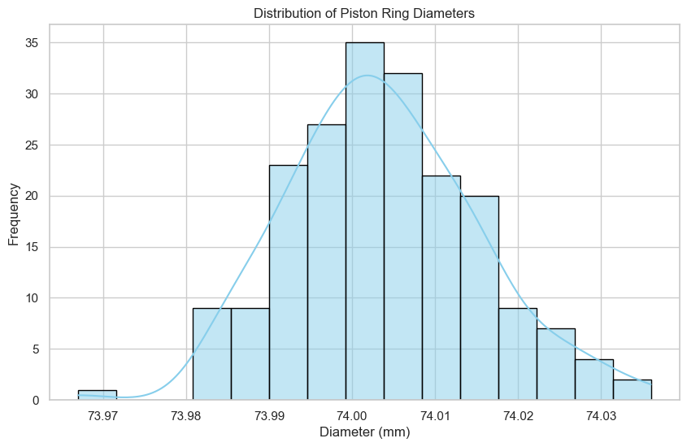

```python
# Plot histogram of diameter
plt.figure(figsize=(10, 6))
sns.histplot(df['diameter'], bins=15, kde=True, color='skyblue', edgecolor='black')
plt.title('Distribution of Piston Ring Diameters')
plt.xlabel('Diameter (mm)')
plt.ylabel('Frequency')
plt.show()
```

**Observations:**

- The diameter measurements are tightly clustered around 74 mm.
- The distribution appears to be approximately normal with minimal variability.
- No significant outliers are evident from the histogram.

## Part a: Summary Statistics for Phase I and Phase II

**Objective:** Load the piston rings dataset and separate the data into Phase I (preliminary, `trial=TRUE`) and Phase II (monitoring, `trial=FALSE`). Calculate and display basic summary statistics for the diameters in each phase, such as mean and standard deviation, to compare overall process characteristics across phases.

```python
# Separate the data into Phase I and Phase II
phase_I = df[df['trial'] == True]
phase_II = df[df['trial'] == False]

# Display the number of samples in each phase
print(f"Number of samples in Phase I: {phase_I['sample'].nunique()}")
print(f"Number of samples in Phase II: {phase_II['sample'].nunique()}")

# Calculate summary statistics for Phase I
summary_phase_I = phase_I.groupby('sample')['diameter'].agg(['mean', 'std']).reset_index()
summary_phase_I.rename(columns={'mean': 'Mean Diameter (mm)', 'std': 'Std Dev (mm)'}, inplace=True)

# Calculate summary statistics for Phase II
summary_phase_II = phase_II.groupby('sample')['diameter'].agg(['mean', 'std']).reset_index()
summary_phase_II.rename(columns={'mean': 'Mean Diameter (mm)', 'std': 'Std Dev (mm)'}, inplace=True)

# Display summary statistics
print("\nSummary Statistics for Phase I:")
display(summary_phase_I.describe())

print("\nSummary Statistics for Phase II:")
display(summary_phase_II.describe())
```

```
Number of samples in Phase I: 25
Number of samples in Phase II: 15

Summary Statistics for Phase I:
```

|  | sample | Mean Diameter (mm) | Std Dev (mm) |
| --- | --- | --- | --- |
| count | 25.000000 | 25.000000 | 25.000000 |
| mean | 13.000000 | 74.001176 | 0.009240 |
| std | 7.359801 | 0.004870 | 0.003520 |
| min | 1.000000 | 73.990200 | 0.002864 |
| 25% | 7.000000 | 73.998200 | 0.007314 |
| 50% | 13.000000 | 74.000800 | 0.008468 |
| 75% | 19.000000 | 74.004200 | 0.011929 |
| max | 25.000000 | 74.010200 | 0.016177 |

```
Summary Statistics for Phase II:
```

|  | sample | Mean Diameter (mm) | Std Dev (mm) |
| --- | --- | --- | --- |
| count | 15.000000 | 15.000000 | 15.000000 |
| mean | 33.000000 | 74.007653 | 0.009762 |
| std | 4.472136 | 0.008619 | 0.002930 |
| min | 26.000000 | 73.992200 | 0.005310 |
| 25% | 29.500000 | 74.002900 | 0.007368 |
| 50% | 33.000000 | 74.007200 | 0.010330 |
| 75% | 36.500000 | 74.012700 | 0.011232 |
| max | 40.000000 | 74.023400 | 0.016547 |

## Part b: X-bar and R Control Charts for Phase I

**Objective:** Create an X-bar and R control chart for the Phase I data to establish baseline control limits for the mean and range of piston ring diameters. Identify any points that fall outside the control limits in Phase I and interpret whether any adjustments might be necessary to bring the process fully under control.

### Understanding X-bar and R Control Charts

- **X-bar Chart:** Monitors the process mean over time.
- **R Chart:** Monitors the process variability (range) over time.

**Key Components:**

- **Centerline (CL):** The average of the sample means (for X-bar) or sample ranges (for R).
- **Upper Control Limit (UCL):** CL + (A2 * R̄) for X-bar; CL + D4 * R̄ for R chart.
- **Lower Control Limit (LCL):** CL - (A2 * R̄) for X-bar; CL - D3 * R̄ for R chart.

**Constants for X-bar and R Charts (for sample size n=5):**

| Chart Type | A2 | D3 | D4 |
| --- | --- | --- | --- |
| X-bar | 0.577 | N/A | N/A |
| R | N/A | 0 | 2.114 |

*Note: D3 is zero for n=5.*

Source: Statistical Process Control (SPC) tables.

```python
# Constants for sample size n=5
A2 = 0.577
D3 = 0
D4 = 2.114

# Calculate sample ranges for Phase I
phase_I = phase_I.copy()
phase_I['range'] = phase_I.groupby('sample')['diameter'].transform(lambda x: x.max() - x.min())

# Calculate average of sample means and ranges
X_bar = phase_I.groupby('sample')['diameter'].mean().mean()
R_bar = phase_I['range'].mean()

# Calculate control limits for X-bar chart
UCL_X = X_bar + A2 * R_bar
LCL_X = X_bar - A2 * R_bar

# Calculate control limits for R chart
UCL_R = D4 * R_bar
LCL_R = D3 * R_bar  # D3 is 0 for n=5

# Add control limits to Phase I DataFrame
phase_I_summary = phase_I.groupby('sample').agg({'diameter': ['mean'], 'range': ['mean']}).reset_index()
phase_I_summary.columns = ['sample', 'mean_diameter', 'mean_range']

phase_I_summary['CL_X'] = X_bar
phase_I_summary['UCL_X'] = UCL_X
phase_I_summary['LCL_X'] = LCL_X

phase_I_summary['CL_R'] = R_bar
phase_I_summary['UCL_R'] = UCL_R
phase_I_summary['LCL_R'] = LCL_R

# Display the control limits
print(f"X-bar Chart Control Limits:")
print(f"Center Line (CL): {X_bar:.4f} mm")
print(f"Upper Control Limit (UCL): {UCL_X:.4f} mm")
print(f"Lower Control Limit (LCL): {LCL_X:.4f} mm")

print("\nR Chart Control Limits:")
print(f"Center Line (CL): {R_bar:.4f} mm")
print(f"Upper Control Limit (UCL): {UCL_R:.4f} mm")
print(f"Lower Control Limit (LCL): {LCL_R:.4f} mm")
```

```
X-bar Chart Control Limits:
Center Line (CL): 74.0012 mm
Upper Control Limit (UCL): 74.0143 mm
Lower Control Limit (LCL): 73.9880 mm

R Chart Control Limits:
Center Line (CL): 0.0228 mm
Upper Control Limit (UCL): 0.0481 mm
Lower Control Limit (LCL): 0.0000 mm
```

### Calculating Control Limits

**X-bar Chart:**

- **Center Line (CL):** 74.0012 mm
- **Upper Control Limit (UCL):** 74.0012 + (0.577 * 0.0228) = 74.0143 mm
- **Lower Control Limit (LCL):** 74.0012 - (0.577 * 0.0228) = 73.9880 mm

**R Chart:**

- **Center Line (CL):** 0.0228 mm
- **Upper Control Limit (UCL):** 2.114 * 0.0228 = 0.0481 mm
- **Lower Control Limit (LCL):** 0.0000 mm (since D3 = 0)

These control limits will be used to plot the X-bar and R charts for Phase I.

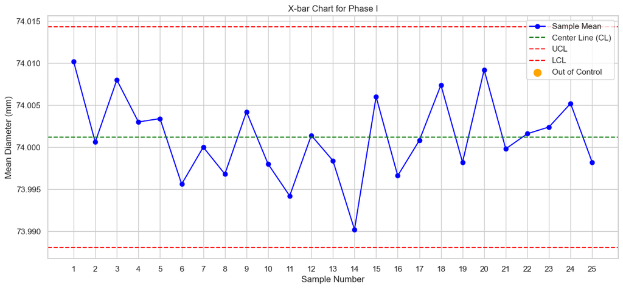

```python
# Plot X-bar Chart for Phase I
plt.figure(figsize=(14, 6))
plt.plot(phase_I_summary['sample'], phase_I_summary['mean_diameter'], marker='o', linestyle='-', color='blue', label='Sample Mean')
plt.axhline(X_bar, color='green', linestyle='--', label='Center Line (CL)')
plt.axhline(UCL_X, color='red', linestyle='--', label='UCL')
plt.axhline(LCL_X, color='red', linestyle='--', label='LCL')

# Highlight points outside control limits
out_of_control_X = phase_I_summary[(phase_I_summary['mean_diameter'] > UCL_X) | (phase_I_summary['mean_diameter'] < LCL_X)]
plt.scatter(out_of_control_X['sample'], out_of_control_X['mean_diameter'], color='orange', s=100, label='Out of Control')

plt.title('X-bar Chart for Phase I')
plt.xlabel('Sample Number')
plt.ylabel('Mean Diameter (mm)')
plt.legend()
plt.xticks(phase_I_summary['sample'])
plt.show()
```

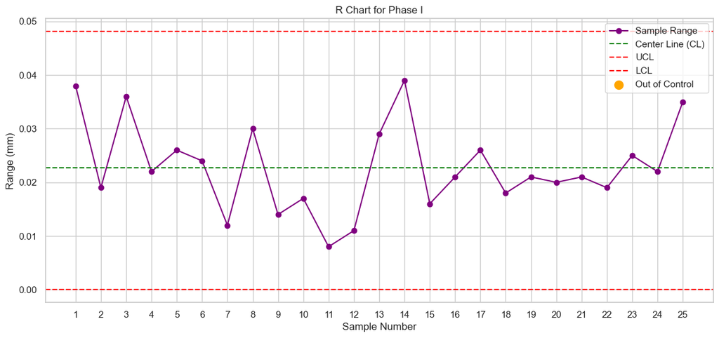

```python
# Plot R Chart for Phase I
plt.figure(figsize=(14, 6))
plt.plot(phase_I_summary['sample'], phase_I_summary['mean_range'], marker='o', linestyle='-', color='purple', label='Sample Range')
plt.axhline(R_bar, color='green', linestyle='--', label='Center Line (CL)')
plt.axhline(UCL_R, color='red', linestyle='--', label='UCL')
plt.axhline(LCL_R, color='red', linestyle='--', label='LCL')

# Highlight points outside control limits
out_of_control_R = phase_I_summary[phase_I_summary['mean_range'] > UCL_R]
plt.scatter(out_of_control_R['sample'], out_of_control_R['mean_range'], color='orange', s=100, label='Out of Control')

plt.title('R Chart for Phase I')
plt.xlabel('Sample Number')
plt.ylabel('Range (mm)')
plt.legend()
plt.xticks(phase_I_summary['sample'])
plt.show()
```

### X-bar Chart Interpretation

- **Observation:** All sample means fall within the control limits (73.9880 mm to 74.0143 mm).
- **Conclusion:** The process mean is stable during Phase I.

### R Chart Interpretation

- **Observation:** All sample ranges fall within the control limit (0.0000 mm to 0.0481 mm).
- **Conclusion:** The process variability is stable during Phase I.

**Overall Conclusion for Part b:**

- Phase I data indicates that the manufacturing process is under control with consistent mean and variability.
- No adjustments are necessary as there are no out-of-control points in either chart.

## Part c: Monitoring Phase II with Control Limits from Phase I

**Objective:** Apply the control limits derived from Phase I to the Phase II samples. Construct X-bar and R charts for Phase II to evaluate the ongoing stability of the forging process. Identify any out-of-control points in Phase II, discuss their significance, and propose possible reasons for any observed shifts or trends.

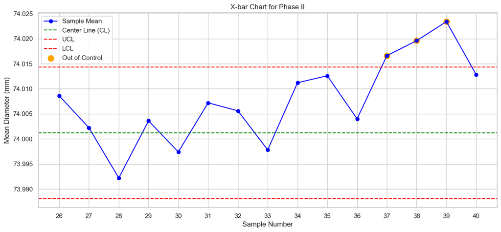

```python
# Prepare Phase II data
phase_II = phase_II.copy()

# Calculate sample ranges for Phase II
phase_II['range'] = phase_II.groupby('sample')['diameter'].transform(lambda x: x.max() - x.min())

# Calculate sample means for Phase II
phase_II_summary = phase_II.groupby('sample').agg({'diameter': ['mean'], 'range': ['mean']}).reset_index()
phase_II_summary.columns = ['sample', 'mean_diameter', 'mean_range']

# Add control limits from Phase I
phase_II_summary['CL_X'] = X_bar
phase_II_summary['UCL_X'] = UCL_X
phase_II_summary['LCL_X'] = LCL_X

phase_II_summary['CL_R'] = R_bar
phase_II_summary['UCL_R'] = UCL_R
phase_II_summary['LCL_R'] = LCL_R

# Plot X-bar Chart for Phase II
plt.figure(figsize=(14, 6))
plt.plot(phase_II_summary['sample'], phase_II_summary['mean_diameter'], marker='o', linestyle='-', color='blue', label='Sample Mean')
plt.axhline(X_bar, color='green', linestyle='--', label='Center Line (CL)')
plt.axhline(UCL_X, color='red', linestyle='--', label='UCL')
plt.axhline(LCL_X, color='red', linestyle='--', label='LCL')

# Highlight points outside control limits
out_of_control_X_II = phase_II_summary[(phase_II_summary['mean_diameter'] > UCL_X) | (phase_II_summary['mean_diameter'] < LCL_X)]
plt.scatter(out_of_control_X_II['sample'], out_of_control_X_II['mean_diameter'], color='orange', s=100, label='Out of Control')

plt.title('X-bar Chart for Phase II')
plt.xlabel('Sample Number')
plt.ylabel('Mean Diameter (mm)')
plt.legend()
plt.xticks(phase_II_summary['sample'])
plt.show()
```

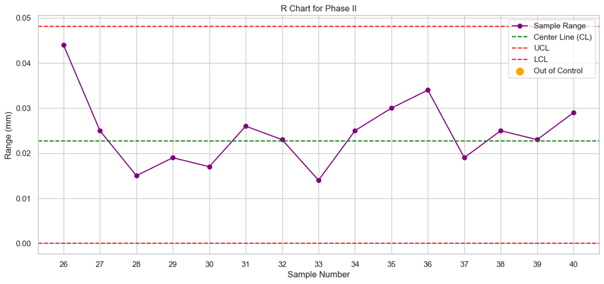

```python
# Plot R Chart for Phase II
plt.figure(figsize=(14, 6))
plt.plot(phase_II_summary['sample'], phase_II_summary['mean_range'], marker='o', linestyle='-', color='purple', label='Sample Range')
plt.axhline(R_bar, color='green', linestyle='--', label='Center Line (CL)')
plt.axhline(UCL_R, color='red', linestyle='--', label='UCL')
plt.axhline(LCL_R, color='red', linestyle='--', label='LCL')

# Highlight points outside control limits
out_of_control_R_II = phase_II_summary[phase_II_summary['mean_range'] > UCL_R]
plt.scatter(out_of_control_R_II['sample'], out_of_control_R_II['mean_range'], color='orange', s=100, label='Out of Control')

plt.title('R Chart for Phase II')
plt.xlabel('Sample Number')
plt.ylabel('Range (mm)')
plt.legend()
plt.xticks(phase_II_summary['sample'])
plt.show()
```

```python
# Identify out-of-control points in Phase II
out_of_control_X_II = phase_II_summary[(phase_II_summary['mean_diameter'] > UCL_X) | (phase_II_summary['mean_diameter'] < LCL_X)]
out_of_control_R_II = phase_II_summary[phase_II_summary['mean_range'] > UCL_R]

print("**Out-of-Control Points in Phase II - X-bar Chart:**")
if out_of_control_X_II.empty:
    print("No out-of-control points in X-bar chart for Phase II.")
else:
    display(out_of_control_X_II[['sample', 'mean_diameter']])

print("\n**Out-of-Control Points in Phase II - R Chart:**")
if out_of_control_R_II.empty:
    print("No out-of-control points in R chart for Phase II.")
else:
    display(out_of_control_R_II[['sample', 'mean_range']])
```

```
**Out-of-Control Points in Phase II - X-bar Chart:**
```

|  | sample | mean_diameter |
| --- | --- | --- |
| 11 | 37 | 74.0166 |
| 12 | 38 | 74.0196 |
| 13 | 39 | 74.0234 |

```
**Out-of-Control Points in Phase II - R Chart:**
No out-of-control points in R chart for Phase II.
```

### Interpretation of Phase II Control Charts

**X-bar Chart:**

- **Out-of-Control Points:** Samples 37, 38, and 39 have mean diameters of 74.0166 mm, 74.0196 mm, and 74.0234 mm respectively.
- **Observation:** These sample means exceed the Upper Control Limit (74.0143 mm).
- **Conclusion:** The process mean has shifted upward during Phase II, indicating potential issues affecting the manufacturing process.

**R Chart:**

- **Observation:** No sample ranges exceed the Upper Control Limit (0.0481 mm).
- **Conclusion:** The process variability remains stable during Phase II.

**Overall Conclusion for Part c:**

- **Process Stability:** The forging process remains stable in terms of variability, as evidenced by the R chart.
- **Mean Shift:** The upward shift in the process mean suggests that while variability is controlled, the process mean has increased beyond acceptable limits.
- **Significance:** This shift may lead to piston rings being outside the specified diameter tolerance, potentially resulting in non-conforming products.

**Recommendations:**

1. **Investigate the Shift in Process Mean:**
   - **Equipment Calibration:** Check if machinery calibration has drifted, causing systematic increases in diameter measurements.
   - **Material Changes:** Verify if there have been changes in raw materials that could affect the diameter.
   - **Operational Procedures:** Ensure that operating procedures have not been altered inadvertently, leading to increased diameters.
2. **Implement Corrective Actions:**
   - **Recalibrate Equipment:** Adjust machinery settings to bring the process mean back to the target of 74.0000 mm.
   - **Review Material Specifications:** Ensure that materials used meet the required specifications without contributing to dimensional shifts.
   - **Training:** Provide additional training to operators to maintain consistent processing practices.
3. **Enhance Monitoring:**
   - **Frequent Sampling:** Increase the frequency of sampling to detect shifts more promptly.
   - **Real-Time Monitoring:** Utilize real-time data acquisition systems to monitor process parameters continuously.
4. **Process Improvement Initiatives:**
   - **Six Sigma Projects:** Initiate Six Sigma projects to identify and eliminate root causes of the mean shift.
   - **Lean Manufacturing:** Incorporate Lean principles to streamline processes and reduce variability.

## Part d: Process Capability Assessment

**Objective:** Assess the process capability for the piston ring diameters, assuming a target diameter of 74 mm and a tolerance of ±0.030 mm. Calculate the Process Capability Index (Cp) based on Phase I data. Comment on whether the process is capable of consistently producing piston rings within the specified tolerance, and discuss any adjustments needed if capability is insufficient.

### Understanding Process Capability Indices

- **Cp (Process Capability):** Measures the potential capability of a process assuming it is centered between the specification limits.

$$ Cp = \frac{USL - LSL}{6\sigma} $$

- **Cpk (Process Capability Index):** Takes into account the process mean's deviation from the target.

$$ Cpk = \min\left(\frac{USL - \mu}{3\sigma}, \frac{\mu - LSL}{3\sigma}\right) $$

**Where:**

- **USL:** Upper Specification Limit
- **LSL:** Lower Specification Limit
- **σ:** Standard deviation of the process
- **μ:** Mean of the process

**Interpretation:**

- **Cp, Cpk ≥ 1.33:** Generally considered capable.
- **Cp, Cpk ≥ 1.67:** Highly capable.
- **Cp, Cpk < 1.33:** Process may require improvement.

```python
# Define specification limits
USL = 74.030  # Upper Specification Limit (74 mm + 0.030 mm)
LSL = 73.970  # Lower Specification Limit (74 mm - 0.030 mm)

# Calculate process standard deviation (σ) from Phase I data
sigma = phase_I_summary['mean_diameter'].std()

# Calculate process mean (μ) from Phase I data
mu = X_bar

# Calculate Cp
Cp = (USL - LSL) / (6 * sigma)

# Calculate Cpk
Cpk_upper = (USL - mu) / (3 * sigma)
Cpk_lower = (mu - LSL) / (3 * sigma)
Cpk = min(Cpk_upper, Cpk_lower)

# Display the results
print(f"Process Mean (μ): {mu:.4f} mm")
print(f"Process Standard Deviation (σ): {sigma:.4f} mm")
print(f"Upper Specification Limit (USL): {USL:.3f} mm")
print(f"Lower Specification Limit (LSL): {LSL:.3f} mm\n")

print(f"Process Capability Index (Cp): {Cp:.3f}")
print(f"Process Capability Index (Cpk): {Cpk:.3f}")
```

```
Process Mean (μ): 74.0012 mm
Process Standard Deviation (σ): 0.0049 mm
Upper Specification Limit (USL): 74.030 mm
Lower Specification Limit (LSL): 73.970 mm

Process Capability Index (Cp): 2.053
Process Capability Index (Cpk): 1.973
```

### Calculating Process Capability Indices

- **Process Mean (μ):** 74.0012 mm
- **Process Standard Deviation (σ):** 0.0049 mm
- **Upper Specification Limit (USL):** 74.030 mm
- **Lower Specification Limit (LSL):** 73.970 mm

**Calculations:**

$ Cp = \frac{74.030 - 73.970}{6 \times 0.0049} = \frac{0.060}{0.0294} \approx 2.053 $

$ Cpk = \min\left(\frac{74.030 - 74.0012}{3 \times 0.0049}, \frac{74.0012 - 73.970}{3 \times 0.0049}\right) = \min\left(\frac{0.0288}{0.0147}, \frac{0.0312}{0.0147}\right) \approx 1.973 $

### Recommendations for Improving Process Capability

1. **Reduce Process Variability:**
   - **Machine Calibration:** Ensure that all forging machines are properly calibrated to maintain consistent diameter measurements.
   - **Process Optimization:** Analyze and optimize the forging parameters (e.g., temperature, pressure) to reduce variability.
2. **Center the Process:**
   - **Adjust Process Mean:** If the process mean is not centered, adjust it to align with the target diameter of 74 mm.
3. **Enhanced Monitoring:**
   - **Real-Time Monitoring:** Implement real-time monitoring systems to detect and correct deviations promptly.
   - **Regular Maintenance:** Schedule regular maintenance to prevent equipment-related variability.
4. **Employee Training:**
   - **Training Programs:** Provide comprehensive training to operators to ensure consistent handling and processing.
   - **Standard Operating Procedures (SOPs):** Develop and enforce SOPs to maintain uniformity in the manufacturing process.
5. **Process Improvement Initiatives:**
   - **Six Sigma:** Apply Six Sigma methodologies to identify and eliminate causes of variability.
   - **Continuous Improvement:** Foster a culture of continuous improvement to consistently enhance process performance.

**Future Actions:**

- **Recalculate Process Capability:** After implementing improvements, recalculate Cp and Cpk to assess the effectiveness of the changes.
- **Control Chart Monitoring:** Continue using X-bar and R charts to monitor ongoing process stability and capability.
- **Customer Feedback:** Incorporate customer feedback to ensure that the piston rings meet quality expectations.